# Restaurant

Oriel Zambrano

December 9, 2016

This is an analysis for [the code challenge](http://https://github.com/TOTVS/MDMStatic/tree/master/code-challenge) forecast

Load and clean data

```r
setwd("~/Documents/Oriel/Notas fiscais")
#LOAD DATA
#first  i changed txt file to json file only modifing the extension
#read text
library(jsonlite)
library(dplyr)
```

```r
library(ggplot2)
library(lubridate)
library(tidyverse)
library(scales)
library(ggthemes)
jsonfile<-readLines("sample.json",skipNul = T)
jsontovts<-fromJSON(paste(jsonfile, collapse = " "))

#Get sales

receita<-cbind(as.numeric(rownames(jsontovts$complemento)), jsontovts$complemento)
names(receita)<- c("id", "vrTotal")

#get and imput purchase dates

dates<-as.data.frame(jsontovts$ide$dhEmi$`$date`)
names(dates)<-"purchasedatehour"
receita<-cbind(receita,dates)
#convert to date type and add time

receita$purchasedate<-as.Date(receita$purchasedatehour, format="%Y-%m-%dT%H:%M")
receita$purchasedatehour<-as.POSIXct(receita$purchasedatehour, format="%Y-%m-%dT%H:%M", tz = "GMT")
receita$time<-format(as.POSIXct(receita$purchasedatehour, format="%Y-%m-%d %H:%M"), format="%H:%M")
receita$hour<-as.numeric(format(as.POSIXct(receita$purchasedatehour, format="%Y-%m-%d %H:%M"), format="%H"))
receita$minutes<-as.numeric(format(as.POSIXct(receita$purchasedatehour, format="%Y-%m-%d %H:%M"), format="%M"))
receita$weekday<- weekdays(receita$purchasedate, abbreviate = T)
receita$wday<-as.numeric(format(as.Date(receita$purchasedate),"%w"))
receita$weeknum<-isoweek(ymd(receita$purchasedate))


#what table number
receita$mesa<-as.numeric(gsub(jsontovts$infAdic$infCpl, pattern = "Mesa", replacement =""))

#mealtype  dinner or lunch Saturdays

for(i in 1:length(receita$hour)) {
  if(receita$hour[i]<17) {receita$meal[i]<-"lunch"} else {receita$meal[i]<-"dinner"}
}

#extract data from orders.

dflist<-jsontovts$dets
for(i in 1:length(dflist)) {
  dflist[[i]]$prod$id<-i}  #introduce ID  for each order
dfto<-list()
for(i in 1:length(dflist)) {
  dfto[[i]]<-dflist[[i]]$prod
}

ordersdf<-do.call(rbind, dfto) #create a data.frame

sort(table(ordersdf$xProd), decreasing = T) #everybody ate buffet. So buffet price is sensible and important.
```

```
##
##         BUFFET   REFRIGERANTE           AGUA           SUCO        CERVEJA
##           1635            778            417            184             93
##            CHA   CERVEJA LATA       LIMONADA       DOCINHOS SUSHI ESPECIAL
##             85             64             56             49             46
##           SAKE  CAFE EXPRESSO      SOBREMESA         WHISKY         TEMAKI
##             36             20             17             16             14
##     CAIPIROSKA       BULE CHA     CAIPIRINHA      YAKISSOBA       HARUMAKI
##              9              8              7              4              3
##        SASHIMI        BACARDI        URAMAKI          VINHO
##              3              1              1              1
```

```r
productorder<-ordersdf %>% group_by(id,xProd) %>% summarise(qCom=sum(qCom)) %>% spread(xProd, qCom)
productvalue<-ordersdf %>% group_by(id,xProd) %>% summarise(vProd=sum(vProd)) %>% spread(xProd, vProd)

names(productorder)<- c("id"  ,           "AGUA"     ,      "BACARDI"  ,      "BUFFET"     ,    "BULE_CHA"    ,  "CAFE_EXPRESSO" ,
"CAIPIRINHA"  ,   "CAIPIROSKA"   ,  "CERVEJA"     ,   "CERVEJA_LATA"  , "CHA"      ,      "DOCINHOS"      ,
"HARUMAKI"    ,   "LIMONADA"     ,  "REFRIGERANTE"  , "SAKE"        ,   "SASHIMI"  ,      "SOBREMESA"    ,
 "SUCO"        ,   "SUSHI_ESPECIAL" ,"TEMAKI"     ,    "URAMAKI"    ,    "VINHO"      ,    "WHISKY"      ,
"YAKISSOBA"   )
names(productvalue)<- c("id"  ,           "AGUA"     ,      "BACARDI"  ,      "BUFFET"     ,    "BULE_CHA"    ,  "CAFE_EXPRESSO" ,
                        "CAIPIRINHA"  ,   "CAIPIROSKA"   ,  "CERVEJA"     ,   "CERVEJA_LATA"  , "CHA"      ,      "DOCINHOS"      ,
                        "HARUMAKI"    ,   "LIMONADA"     ,  "REFRIGERANTE"  , "SAKE"        ,   "SASHIMI"  ,      "SOBREMESA"    ,
                        "SUCO"        ,   "SUSHI_ESPECIAL" ,"TEMAKI"     ,    "URAMAKI"    ,    "VINHO"      ,    "WHISKY"      ,
                        "YAKISSOBA"   )


productorder[is.na(productorder)]<-0
productvalue[is.na(productvalue)]<-0

qcomandprodctvalue<-merge(productorder,productvalue, by = "id",suffixes = c(".qCom", ".Vpaid"))

#merge in the big dataframe
receita<-merge(x =receita, y =qcomandprodctvalue, all.x = T, all.y = F)
```

There are no important difference between average sales by table code. But tables 1 to 50 sells more than tabeles 51 to 99..( tehere are some wierd tables never used, like 12, 20, 50)

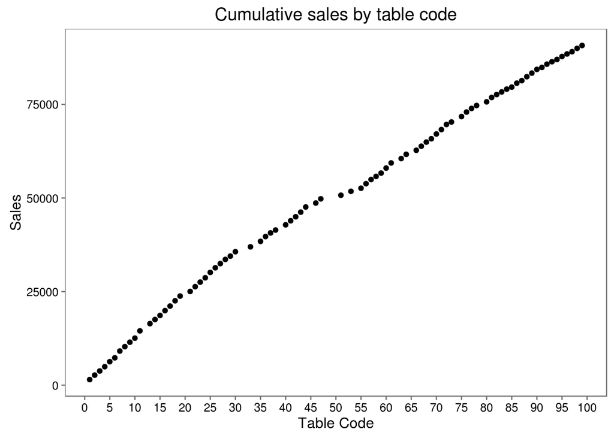

```r
receita %>%group_by(mesa) %>% summarise(sales=sum(vrTotal)) %>% mutate(CumulativeSales=cumsum(sales)) %>%
  ggplot()+geom_point(aes(x = mesa, y = CumulativeSales)) + labs(title= "Cumulative sales by table code", x= "Table Code", y ="Sales") +
  theme_few() +scale_x_continuous(breaks = seq(0,100,by = 5))
```

## Pattern

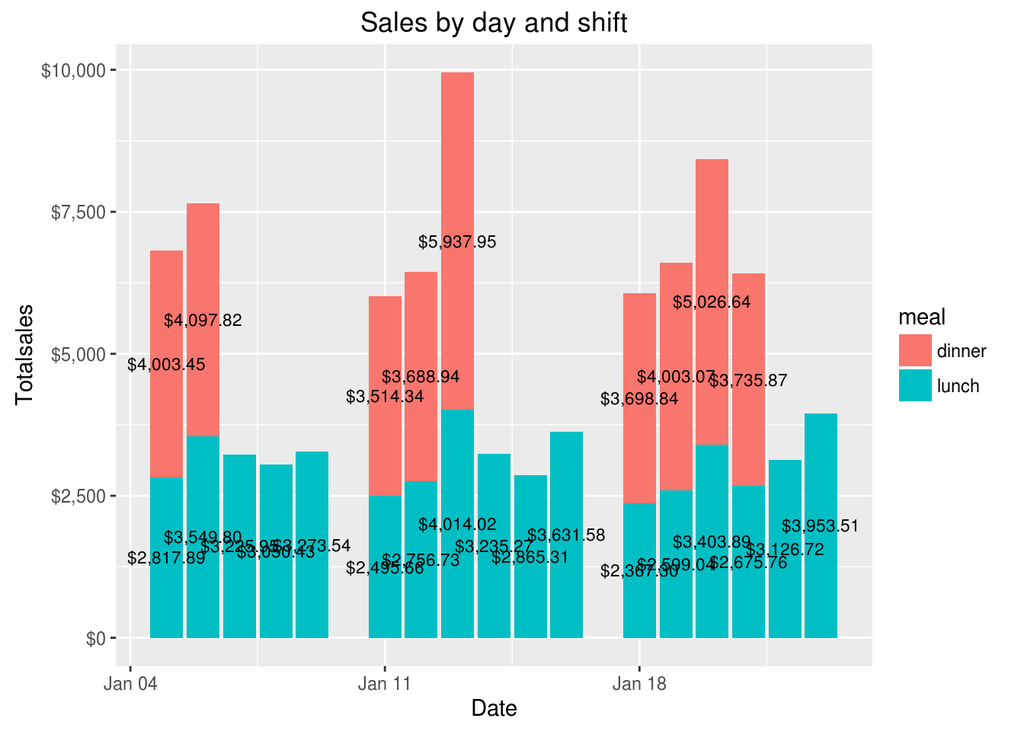

```r
receita %>% group_by(purchasedate, meal) %>% summarise(sales=sum(vrTotal)) %>% arrange(desc(meal)) %>% mutate(pos=cumsum(sales)-0.5*sales) %>%
  ggplot() + geom_bar(aes(x = purchasedate, y = sales, fill=meal, label=sales), stat = "identity") +
  geom_text(aes(x = purchasedate, y = pos, fill=meal, label=dollar(sales)), size=3) + scale_y_continuous(labels=dollar_format()) +labs(title="Sales by day and shift", x="Date", y="Totalsales")
```

## Correlations

There are no strong relationship on features, just buffet cunsumption and sales the other featues have no strong relationship and ore have obvious relations. Like when consume whisky there are more sales for the obvious reason that whisky is spensive.

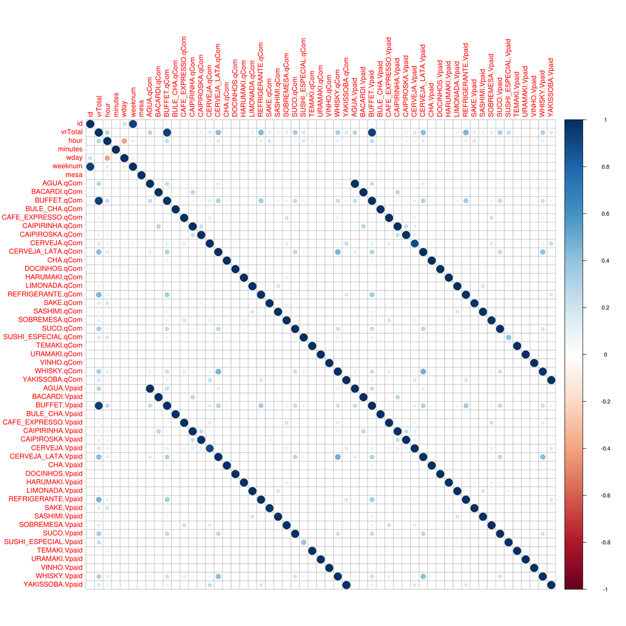

```r
#CORPPLOT
corrmatrix<-receita %>% select(-c(weekday,time, meal,purchasedatehour,purchasedate) ) %>% cor()
library(corrplot)
corrplot::corrplot(corrmatrix)
```

## Forecast

The next week (week 4) there will be sales for $ 39 281

```r
#Naive Lunch forecast
dflunch<-receita %>% group_by(weeknum=as.numeric(weeknum),weekday, purchasedate, meal) %>% arrange(desc(meal)) %>% summarise(total=sum(vrTotal))
library(caret)
#randomforest
control <- trainControl(method="repeatedcv", number=6, repeats=4, search="grid")
set.seed(1254)
tunegrid <- expand.grid(.mtry=3, .ntree=500)
library(randomForest)
```

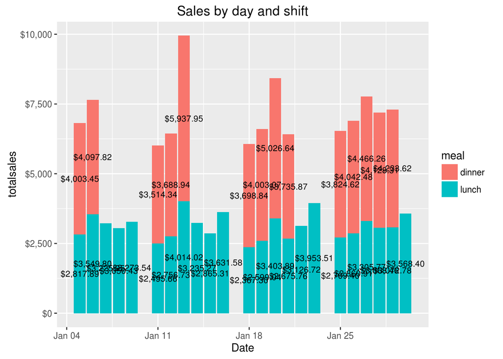

```r
modellinardflunchrf <-train(total~weeknum+weekday+meal,data = dflunch, method="rf", metric="RMSE", ntree=1000, trControl=control)

#create empty dates and shifts
dflunch[27:37,1]<- rep(4)
dflunch[27:37,2]<- c("Seg","Ter","Qua","Qui","Sex","Sáb","Seg","Ter","Qua","Qui","Sex")
dflunch[27:32,3] <- seq(as.Date("2016-01-25"), as.Date("2016-01-30"), by = "day")
dflunch[33:37,3] <- seq(as.Date("2016-01-25"), as.Date("2016-01-29"), by = "day")
dflunch[27:32,4]<-rep("lunch")
dflunch[33:37,4]<-rep("dinner")


#forecast random forest
dflunch[27:37,5]<- predict(modellinardflunchrf, dflunch[27:37,])

#Plot Everything
dflunch %>% group_by(purchasedate, meal) %>% summarise(sales=sum(total)) %>% arrange(desc(meal)) %>% mutate(pos=cumsum(sales)-0.5*sales) %>%
  ggplot() + geom_bar(aes(x = purchasedate, y = sales, fill=meal, label=sales), stat = "identity") +
  geom_text(aes(x = purchasedate, y = pos, fill=meal, label=dollar(sales)), size=3) + scale_y_continuous(labels=dollar_format()) +labs(title="Sales by day and shift", x="Date", y="totalsales")
```

## forecast orders

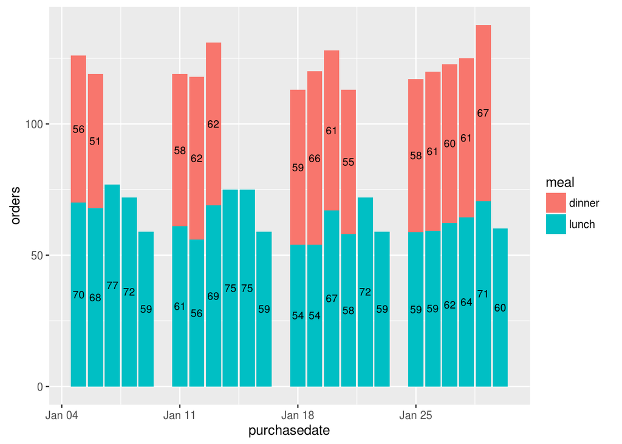

```r
#Forecast people at the restaurant

dforders<-receita %>% group_by(weeknum=as.numeric(weeknum),weekday, purchasedate, meal) %>% arrange(desc(meal)) %>% summarise(totalorders=n_distinct(id))

#randomforest
control <- trainControl(method="repeatedcv", number=6, repeats=4, search="grid")
tunegridFOOD<- expand.grid(.mtry=c(3,4,5))
modellinardflunchrf <-train(totalorders~weeknum+weekday+meal,data = dforders, method="rf", metric="RMSE", ntree=500, trControl=control, tuneGrid=tunegridFOOD)

#create empty dates and shifts
dforders[27:37,1]<- rep(4)
dforders[27:37,2]<- c("Seg","Ter","Qua","Qui","Sex","Sáb","Seg","Ter","Qua","Qui","Sex")
dforders[27:32,3] <- seq(as.Date("2016-01-25"), as.Date("2016-01-30"), by = "day")
dforders[33:37,3] <- seq(as.Date("2016-01-25"), as.Date("2016-01-29"), by = "day")
dforders[27:32,4]<-rep("lunch")
dforders[33:37,4]<-rep("dinner")


#random forest
dforders[27:37,5]<- predict(modellinardflunchrf, dforders[27:37,])

dforders %>% group_by(purchasedate, meal) %>% summarise(orders=sum(totalorders)) %>% arrange(desc(meal)) %>% mutate(pos=cumsum(orders)-0.5*orders) %>%
  ggplot() + geom_bar(aes(x = purchasedate, y = orders, fill=meal, label=orders), stat = "identity") +
  geom_text(aes(x = purchasedate, y = pos, fill=meal, label=round(orders)), size=3)
```

```r
#Forecast orders
dforders[27:37,] %>% arrange(purchasedate) %>% print(n=30)
```

```
## Source: local data frame [11 x 5]
## Groups: weeknum, weekday, purchasedate [6]
##
##    weeknum weekday purchasedate   meal totalorders
##      (dbl)   (chr)       (date)  (chr)       (dbl)
## 1        4     Qua   2016-01-27  lunch    62.38164
## 2        4     Qua   2016-01-27 dinner    60.33692
## 3        4     Qui   2016-01-28  lunch    64.34272
## 4        4     Qui   2016-01-28 dinner    60.73391
## 5        4     Sáb   2016-01-30  lunch    60.12104
## 6        4     Seg   2016-01-25  lunch    58.78408
## 7        4     Seg   2016-01-25 dinner    58.38839
## 8        4     Sex   2016-01-29  lunch    70.58436
## 9        4     Sex   2016-01-29 dinner    67.16504
## 10       4     Ter   2016-01-26  lunch    59.30602
## 11       4     Ter   2016-01-26 dinner    60.61613
```

```r
dforders %>% group_by(weeknum) %>% summarise(orders=round(sum(totalorders)))
```

```
## # A tibble: 4 × 2
##   weeknum orders
##     <dbl>  <dbl>
## 1       1    453
## 2       2    577
## 3       3    605
## 4       4    683
```

## Forecast food, sodas, and aguas.

Just for buffet, sodas and water, are the products with more stock attention.

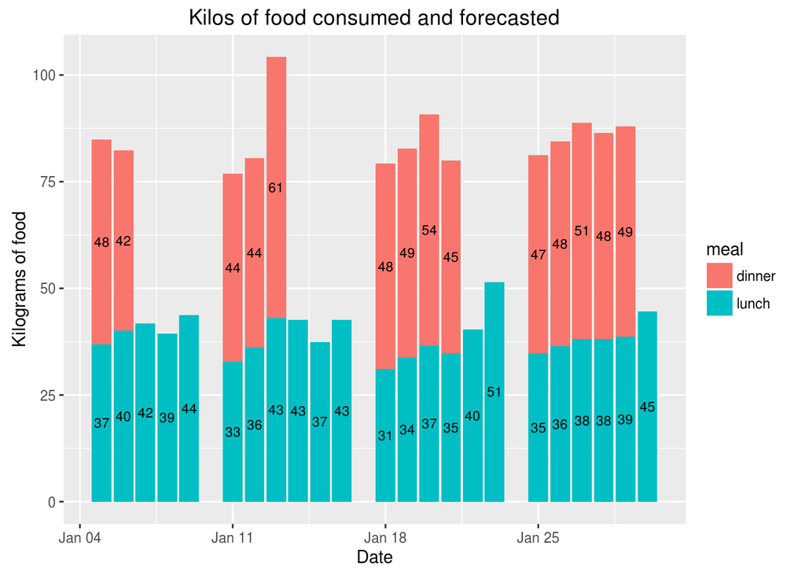

```r
#QUANTITY OF FOOD

dffood<-receita %>% group_by(weeknum=as.numeric(weeknum),weekday, purchasedate, meal) %>% arrange(desc(meal)) %>% summarise(totalfood=sum(BUFFET.qCom))
#randomforest
control <- trainControl(method="repeatedcv", number=6, repeats=4, search="grid")
set.seed(1254)
modellinardflunchrf <-train(totalfood~weeknum+weekday+meal,data = dffood, method="rf", metric="RMSE", ntree=300, trControl=control)
#create empty dates and shifts
dffood[27:37,1]<- rep(4)
dffood[27:37,2]<- c("Seg","Ter","Qua","Qui","Sex","Sáb","Seg","Ter","Qua","Qui","Sex")
dffood[27:32,3] <- seq(as.Date("2016-01-25"), as.Date("2016-01-30"), by = "day")
dffood[33:37,3] <- seq(as.Date("2016-01-25"), as.Date("2016-01-29"), by = "day")
dffood[27:32,4]<-rep("lunch")
dffood[33:37,4]<-rep("dinner")

#forecast random forest
dffood[27:37,5]<- predict(modellinardflunchrf, dflunch[27:37,])

dffood %>% group_by(purchasedate, meal) %>% summarise(totalfood=sum(totalfood)) %>% arrange(desc(meal)) %>% mutate(pos=cumsum(totalfood)-0.5*totalfood) %>%
  ggplot() + geom_bar(aes(x = purchasedate, y = totalfood, fill=meal, label=totalfood), stat = "identity") +
  geom_text(aes(x = purchasedate, y = pos, fill=meal, label=round(totalfood)), size=3) +labs(title="Kilos of food consumed and forecasted", x="Date", y="Kilograms of food")
```

The next week there will be consumed 473 kilos of food.

```r
#Forecast Buffet
dffood[27:37,] %>% arrange(purchasedate) %>% print(n=30)
```

```
## Source: local data frame [11 x 5]
## Groups: weeknum, weekday, purchasedate [6]
##
##    weeknum weekday purchasedate   meal totalfood
##      (dbl)   (chr)       (date)  (chr)     (dbl)
## 1        4     Qua   2016-01-27  lunch  38.18300
## 2        4     Qua   2016-01-27 dinner  50.59350
## 3        4     Qui   2016-01-28  lunch  38.10965
## 4        4     Qui   2016-01-28 dinner  48.26393
## 5        4     Sáb   2016-01-30  lunch  44.63764
## 6        4     Seg   2016-01-25  lunch  34.70635
## 7        4     Seg   2016-01-25 dinner  46.52601
## 8        4     Sex   2016-01-29  lunch  38.67505
## 9        4     Sex   2016-01-29 dinner  49.25852
## 10       4     Ter   2016-01-26  lunch  36.45919
## 11       4     Ter   2016-01-26 dinner  47.98950
```

```r
dffood %>% group_by(weeknum) %>% summarise(food=(sum(totalfood)))
```

```
## # A tibble: 4 × 2
##   weeknum     food
##     <dbl>    <dbl>
## 1       1 292.2760
## 2       2 384.1650
## 3       3 424.5730
## 4       4 473.4024
```

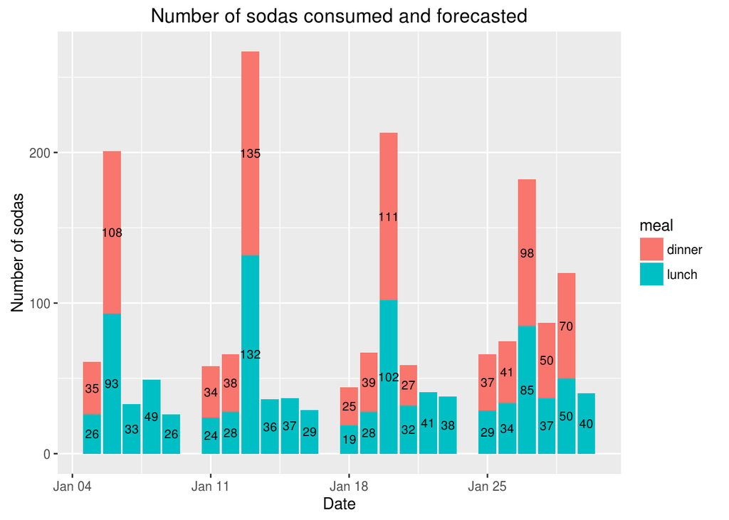

```r
#Forecast for Refrigerante (soda)

dfrefri<-receita %>% group_by(weeknum=as.numeric(weeknum),weekday, purchasedate, meal) %>% arrange(desc(meal)) %>% summarise(totalrefri=sum(REFRIGERANTE.qCom))
#randomforest
control <- trainControl(method="repeatedcv", number=6, repeats=4, search="grid")
set.seed(1254)
modellinardflunchrf <-train(totalrefri~weeknum+weekday+meal,data = dfrefri, method="rf", metric="RMSE", ntree=300, trControl=control)
#create empty dates and shifts
dfrefri[27:37,1]<- rep(4)
dfrefri[27:37,2]<- c("Seg","Ter","Qua","Qui","Sex","Sáb","Seg","Ter","Qua","Qui","Sex")
dfrefri[27:32,3] <- seq(as.Date("2016-01-25"), as.Date("2016-01-30"), by = "day")
dfrefri[33:37,3] <- seq(as.Date("2016-01-25"), as.Date("2016-01-29"), by = "day")
dfrefri[27:32,4]<-rep("lunch")
dfrefri[33:37,4]<-rep("dinner")

#forecast random forest
dfrefri[27:37,5]<- predict(modellinardflunchrf, dfrefri[27:37,])

dfrefri %>% group_by(purchasedate, meal) %>% summarise(totalrefri=sum(totalrefri)) %>% arrange(desc(meal)) %>% mutate(pos=cumsum(totalrefri)-0.5*totalrefri) %>%
  ggplot() + geom_bar(aes(x = purchasedate, y = totalrefri, fill=meal, label=totalrefri), stat = "identity") +
  geom_text(aes(x = purchasedate, y = pos, fill=meal, label=round(totalrefri)), size=3) + scale_y_continuous() +labs(title="Number of sodas consumed and forecasted", x="Date", y="Number of sodas")
```

The next week there will be consumed 569 sodas.

```r
#Forecast soda
dfrefri[27:37,] %>% arrange(purchasedate) %>% print(n=30)
```

```
## Source: local data frame [11 x 5]
## Groups: weeknum, weekday, purchasedate [6]
##
##    weeknum weekday purchasedate   meal totalrefri
##      (dbl)   (chr)       (date)  (chr)      (dbl)
## 1        4     Qua   2016-01-27  lunch   84.59422
## 2        4     Qua   2016-01-27 dinner   97.58672
## 3        4     Qui   2016-01-28  lunch   36.86744
## 4        4     Qui   2016-01-28 dinner   50.13856
## 5        4     Sáb   2016-01-30  lunch   40.08289
## 6        4     Seg   2016-01-25  lunch   28.63733
## 7        4     Seg   2016-01-25 dinner   37.23194
## 8        4     Sex   2016-01-29  lunch   49.82261
## 9        4     Sex   2016-01-29 dinner   70.15906
## 10       4     Ter   2016-01-26  lunch   33.58244
## 11       4     Ter   2016-01-26 dinner   41.10178
```

```r
dfrefri %>% group_by(weeknum) %>% summarise(refri=(sum(totalrefri)))
```

```
## # A tibble: 4 × 2
##   weeknum   refri
##     <dbl>   <dbl>
## 1       1 370.000
## 2       2 493.000
## 3       3 462.000
## 4       4 569.805
```

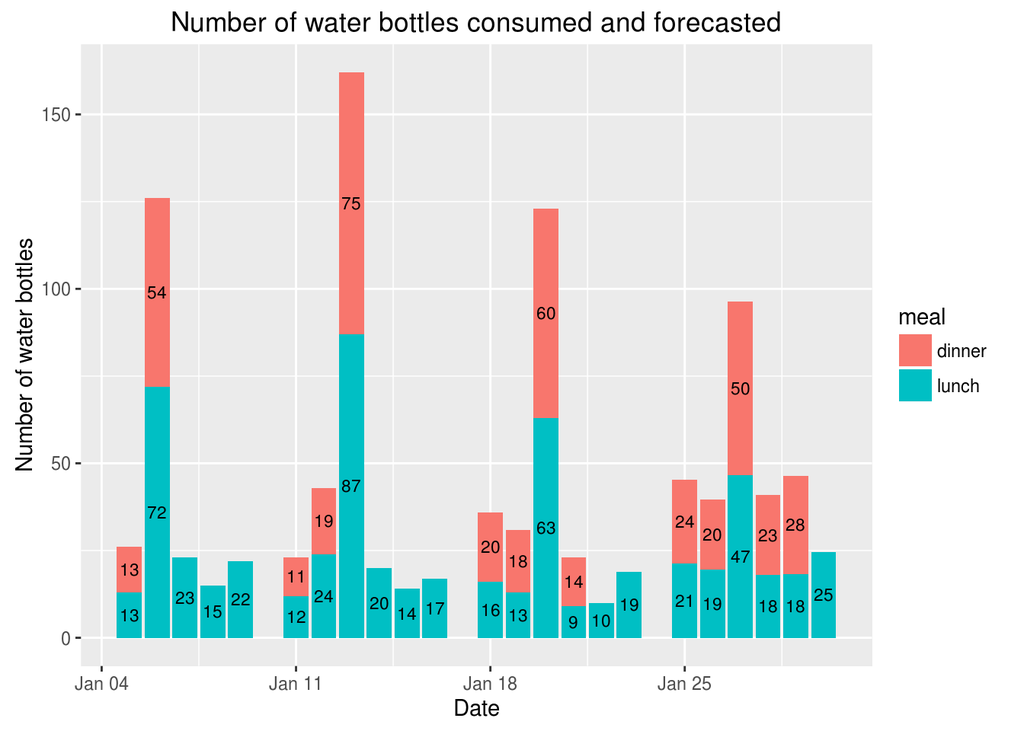

```r
dfagua<-receita %>% group_by(weeknum=as.numeric(weeknum),weekday, purchasedate, meal) %>% arrange(desc(meal)) %>% summarise(totalagua=sum(AGUA.qCom))
#randomforest
control <- trainControl(method="repeatedcv", number=6, repeats=4, search="grid")
set.seed(1254)
modellinardflunchrf <-train(totalagua~weeknum+weekday+meal,data = dfagua, method="rf", metric="RMSE", ntree=100, trControl=control)
#create empty dates and shifts
dfagua[27:37,1]<- rep(4)
dfagua[27:37,2]<- c("Seg","Ter","Qua","Qui","Sex","Sáb","Seg","Ter","Qua","Qui","Sex")
dfagua[27:32,3] <- seq(as.Date("2016-01-25"), as.Date("2016-01-30"), by = "day")
dfagua[33:37,3] <- seq(as.Date("2016-01-25"), as.Date("2016-01-29"), by = "day")
dfagua[27:32,4]<-rep("lunch")
dfagua[33:37,4]<-rep("dinner")

#forecast random forest
dfagua[27:37,5]<- predict(modellinardflunchrf, dfagua[27:37,])

dfagua %>% group_by(purchasedate, meal) %>% summarise(totalagua=sum(totalagua)) %>% arrange(desc(meal)) %>% mutate(pos=cumsum(totalagua)-0.5*totalagua) %>%
  ggplot() + geom_bar(aes(x = purchasedate, y = totalagua, fill=meal, label=totalagua), stat = "identity") +
  geom_text(aes(x = purchasedate, y = pos, fill=meal, label=round(totalagua)), size=3) + scale_y_continuous() +labs(title="Number of water bottles consumed and forecasted", x="Date", y="Number of water bottles")
```

```r
dfagua[27:37,] %>% arrange(purchasedate) %>% print(n=30)
```

```
## Source: local data frame [11 x 5]
## Groups: weeknum, weekday, purchasedate [6]
##
##    weeknum weekday purchasedate   meal totalagua
##      (dbl)   (chr)       (date)  (chr)     (dbl)
## 1        4     Qua   2016-01-27  lunch  46.69533
## 2        4     Qua   2016-01-27 dinner  49.67117
## 3        4     Qui   2016-01-28  lunch  17.99400
## 4        4     Qui   2016-01-28 dinner  22.97000
## 5        4     Sáb   2016-01-30  lunch  24.58050
## 6        4     Seg   2016-01-25  lunch  21.20250
## 7        4     Seg   2016-01-25 dinner  24.03883
## 8        4     Sex   2016-01-29  lunch  18.34733
## 9        4     Sex   2016-01-29 dinner  27.99333
## 10       4     Ter   2016-01-26  lunch  19.45550
## 11       4     Ter   2016-01-26 dinner  20.14733
```

```r
dfagua %>% group_by(weeknum) %>% summarise(aguas=(sum(totalagua)))
```

```
## # A tibble: 4 × 2
##   weeknum    aguas
##     <dbl>    <dbl>
## 1       1 212.0000
## 2       2 279.0000
## 3       3 242.0000
## 4       4 293.0958
```

```r
finaldataforecasted<-data.frame(dflunch$purchasedate,
                   dflunch$meal,  dflunch$total, dforders$totalorders, dffood$totalfood, dfrefri$totalrefri, dfagua$totalagua)

print(finaldataforecasted)
```

```
##    dflunch.purchasedate dflunch.meal dflunch.total dforders.totalorders
## 1            2016-01-06       dinner      4097.820             51.00000
## 2            2016-01-06        lunch      3549.800             68.00000
## 3            2016-01-07        lunch      3225.950             77.00000
## 4            2016-01-09        lunch      3273.540             59.00000
## 5            2016-01-08        lunch      3050.430             72.00000
## 6            2016-01-05       dinner      4003.450             56.00000
## 7            2016-01-05        lunch      2817.890             70.00000
## 8            2016-01-13       dinner      5937.950             62.00000
## 9            2016-01-13        lunch      4014.020             69.00000
## 10           2016-01-14        lunch      3235.270             75.00000
## 11           2016-01-16        lunch      3631.580             59.00000
## 12           2016-01-11       dinner      3514.340             58.00000
## 13           2016-01-11        lunch      2495.660             61.00000
## 14           2016-01-15        lunch      2865.310             75.00000
```

[output cut: 61 more lines]